# Sparkify Churn Analysis

## Project Definition

Here we analyse a simulated event log file from a fictional Spotify-like music streaming service called Sparkify, in an attempt to predict which users churned. We define churn as a user on paid subscription downgrading to free subscription, or cancelling the service altogether.

Specifically, we will attempt to predict whether a given user churned during the 2 months covered by the data, based on their activity during this period. We will explore and clean the data, engineer any needed features, and train several classification models to determine which is best suited to the task.

Precision and recall will both be important, so the models will be evaluated based on their F-score. For example, it would be useful for a marketing department to receive a list of users likely to churn, so that a marketing intervention could take place. However, it would not be so useful if the list included lots of users who were not likely to churn, potentially incurring unnecessary expense.

This project is a capstone project from the Udacity Data Scientist nanodegree, and the data is provided by Udacity.

## Setup

This notebook will complete analysis of the full dataset in approximately 25 minutes using the setup specified here. The notebook was run on an Amazon Web Services EMR cluster with the following advanced options:

- Release label: emr-6.3.0
- Hadoop distribution: Amazon 3.2.1
- Applications: Spark 3.1.1, JupyterEnterpriseGateway 2.1.0, JupyterHub 1.2.0, Ganglia 3.7.2, Livy 0.7.0
- Software configuration:

  [

  ```
    {
    "classification" : "spark",
    "properties" : {
                    "maximizeResourceAllocation" : "true"
                    },
    "configurations" : []
    },
    {
    "classification" : "livy-conf",
    "properties" : {
                   "livy.server.session.timeout" : "5h"
                   },
    "configurations" : []
    }
  ```

  ]
- Master: 1 m5.xlarge
- Core: 2 m5.xlarge for sample dataset, 8 m5.xlarge for full dataset
- EC2 key pair: A .ppk key pair

After following the instructions at https://docs.aws.amazon.com/emr/latest/ManagementGuide/emr-connect-ssh-prereqs.html to allow SSH access, the .ppk key was used in conjuction with PuTTY to install pandas and matplotlib on the master node using the following commands:

- `sudo yum -y install python3-devel-3.7.10`
- `sudo pip3 install cython==0.29.24`
- `sudo pip3 install pandas==1.3.2`
- `sudo pip3 install matplotlib==3.4.3`

N.B. Bootstrapping these commands will not work as numpy will later be overridden by an earlier version - see https://forums.aws.amazon.com/thread.jspa?messageID=989210&tstart=0.

### Imports

```python
# import libraries
import datetime
import numpy as np
import pandas as pd
import matplotlib.pyplot as plt
from pyspark import StorageLevel
from pyspark.sql import SparkSession, Window
from pyspark.sql import functions as F
from pyspark.sql.types import IntegerType, LongType, FloatType, DoubleType, StringType, StructType, StructField
from pyspark.ml.feature import VectorAssembler, StandardScaler, PCA
from pyspark.ml.classification import LogisticRegression, RandomForestClassifier, GBTClassifier
from pyspark.ml import Pipeline
from pyspark.ml.pipeline import PipelineModel
from pyspark.ml.tuning import TrainValidationSplit, ParamGridBuilder
from pyspark.ml.evaluation import MulticlassClassificationEvaluator

sc.setCheckpointDir('checkpoints')
```

```
Starting Spark application
```

| ID | YARN Application ID | Kind | State | Spark UI | Driver log | Current session? |
| --- | --- | --- | --- | --- | --- | --- |
| 22 | application_1631861419353_0023 | pyspark | idle | [Link](http://ip-172-31-47-108.eu-west-2.compute.internal:20888/proxy/application_1631861419353_0023/) | [Link](http://ip-172-31-33-122.eu-west-2.compute.internal:8042/node/containerlogs/container_1631861419353_0023_01_000001/livy) | ✔ |

```
SparkSession available as 'spark'.
```

```python
start = datetime.datetime.now()
print(start.strftime("%H:%M:%S"))
```

```
16:13:47
```

We note that a spark session has been created for us automatically.

### Loading Dataset

We can load a sample dataset to quickly verify the code runs correctly, or the full dataset for in-depth analysis which will take longer to complete. We partition the data according to the number of cores we expect to have available, by `userID`, and sorted by `artist`, as this optimises our feature engineering.

Set `sample_data` here to `True` for quick execution. The notebook is saved with output and commentary relating to the full dataset (`sample_data` `False`).

```python
# Set sample_data as True to analyse sample dataset, or False to analyse full dataset
sample_data = False

# Set filepath and partition number relevant to the dataset
if sample_data:
    sparkify_data = "s3n://udacity-dsnd/sparkify/mini_sparkify_event_data.json"
    partitions = 24
else:
    sparkify_data = "s3n://udacity-dsnd/sparkify/sparkify_event_data.json"
    partitions = 96

schema = StructType([ \
    StructField('artist',StringType(),True), \
    StructField('auth',StringType(),True), \
    StructField('firstName',StringType(),True), \
    StructField('gender', StringType(), True), \
    StructField('itemInSession', LongType(), True), \
    StructField('lastName',StringType(),True), \
    StructField('length', DoubleType(), True), \
    StructField('level', StringType(), True), \
    StructField('location',StringType(),True), \
    StructField('method',StringType(),True), \
    StructField('page',StringType(),True), \
    StructField('registration',LongType(),True), \
    StructField('sessionId',LongType(),True), \
    StructField('song',StringType(),True), \
    StructField('status',LongType(),True), \
    StructField('ts',LongType(),True), \
    StructField('userAgent',StringType(),True), \
    StructField('userId',StringType(),True), \
  ])

# Read in dataset
events_df = spark.read.json(sparkify_data, schema) \
                 .repartition(partitions, 'userId') \
                 .sortWithinPartitions('artist') \
                 .persist(StorageLevel.MEMORY_ONLY)
```

## Exploratory Data Analysis

We explore the structure of the data, consider how to summarise the data in each column as features for the model, and establish what cleaning might be necessary. If the full dataset is loaded, we explore a sample of this.

```python
# Select sample of users from event_df unless already working on the sample dataset.
if sample_data:
    explore_df = events_df
else:
    sample_users = events_df.select('userId') \
                            .distinct() \
                            .sample(False, 0.01, 42)

    explore_df = events_df.join(sample_users, 'userId') \

explore_df = explore_df.persist(StorageLevel.MEMORY_ONLY)
```

We check how many rows there are in total.

```python
explore_df.count()
```

```
236938
```

```python
explore_df.show(1)
```

```
+-------+------+---------+---------+------+-------------+--------+------+-----+--------------------+------+----------+-------------+---------+----+------+-------------+--------------------+
| userId|artist|     auth|firstName|gender|itemInSession|lastName|length|level|            location|method|      page| registration|sessionId|song|status|           ts|           userAgent|
+-------+------+---------+---------+------+-------------+--------+------+-----+--------------------+------+----------+-------------+---------+----+------+-------------+--------------------+
|1232486|  null|Logged In|   Isabel|     F|            1|  Pierce|  null| paid|Phoenix-Mesa-Scot...|   PUT|Add Friend|1536802415000|    64435|null|   307|1539667759000|Mozilla/5.0 (X11;...|
+-------+------+---------+---------+------+-------------+--------+------+-----+--------------------+------+----------+-------------+---------+----+------+-------------+--------------------+
only showing top 1 row
```

We look at how a user's events typically stack up over time.

```python
firstId = explore_df.limit(1).select('userId').collect()[0][0]

explore_df.filter(explore_df.userId == firstId) \
          .orderBy('ts') \
          .show(5)
```

```
+-------+--------------------+---------+---------+------+-------------+--------+---------+-----+--------------------+------+---------------+-------------+---------+--------------------+------+-------------+--------------------+
| userId|              artist|     auth|firstName|gender|itemInSession|lastName|   length|level|            location|method|           page| registration|sessionId|                song|status|           ts|           userAgent|
+-------+--------------------+---------+---------+------+-------------+--------+---------+-----+--------------------+------+---------------+-------------+---------+--------------------+------+-------------+--------------------+
|1232486|                null|Logged In|   Isabel|     F|            0|  Pierce|     null| paid|Phoenix-Mesa-Scot...|   GET|           Home|1536802415000|    13012|                null|   200|1538355113000|Mozilla/5.0 (X11;...|
|1232486|        Phil Collins|Logged In|   Isabel|     F|            1|  Pierce|175.12444| paid|Phoenix-Mesa-Scot...|   PUT|       NextSong|1536802415000|    13012|You Can't Hurry Love|   200|1538355307000|Mozilla/5.0 (X11;...|
|1232486|        Cypress Hill|Logged In|   Isabel|     F|            2|  Pierce|197.14567| paid|Phoenix-Mesa-Scot...|   PUT|       NextSong|1536802415000|    13012|       Light Another|   200|1538355482000|Mozilla/5.0 (X11;...|
|1232486|                null|Logged In|   Isabel|     F|            3|  Pierce|     null| paid|Phoenix-Mesa-Scot...|   PUT|Add to Playlist|1536802415000|    13012|                null|   200|1538355500000|Mozilla/5.0 (X11;...|
|1232486|The Michael Schen...|Logged In|   Isabel|     F|            4|  Pierce|250.53995| paid|Phoenix-Mesa-Scot...|   PUT|       NextSong|1536802415000|    13012|Armed And Ready (...|   200|1538355679000|Mozilla/5.0 (X11;...|
+-------+--------------------+---------+---------+------+-------------+--------+---------+-----+--------------------+------+---------------+-------------+---------+--------------------+------+-------------+--------------------+
only showing top 5 rows
```

We check for missing data.

```python
# Count rows per column where data is missing, retaining column names
explore_df.select([F.count(F.when(F.isnan(c) | F.col(c).isNull(), c)).alias(c) for c in explore_df.columns]) \
          .show()
```

```
+------+------+----+---------+------+-------------+--------+------+-----+--------+------+----+------------+---------+-----+------+---+---------+
|userId|artist|auth|firstName|gender|itemInSession|lastName|length|level|location|method|page|registration|sessionId| song|status| ts|userAgent|
+------+------+----+---------+------+-------------+--------+------+-----+--------+------+----+------------+---------+-----+------+---+---------+
|     0| 44028|   0|        0|     0|            0|       0| 44028|    0|       0|     0|   0|           0|        0|44028|     0|  0|        0|
+------+------+----+---------+------+-------------+--------+------+-----+--------+------+----+------------+---------+-----+------+---+---------+
```

We expect missing data for artist, length, and song, as these columns only apply to song plays. For other columns, very little data is missing, so we can remove these rows.

```python
explore_df = explore_df.dropna(subset=['gender', 'location', 'registration', 'userAgent'])
```

We take a more detailed look at the columns of interest.

### level

We're only interested in users on a paid subscription, so we check the possible values for `level`.

```python
explore_df.select('level') \
          .distinct() \
          .show()
```

```
+-----+
|level|
+-----+
| free|
| paid|
+-----+
```

Nothing unexpected here. We need to retain the rows where `level` is 'paid'.

We count the number of paid users in the full events dataset we've loaded.

```python
events_df.filter(events_df.level == 'paid') \
         .agg(F.countDistinct('userID')) \
         .show()
```

```
+-------------+
|count(userID)|
+-------------+
|        16185|
+-------------+
```

### auth

As we're analysing behaviour by user, events triggered by logged out users won't be useful. We check the possible values for `auth` when the user level is `paid`.

```python
explore_df.filter(explore_df.level == 'paid') \
          .select('auth') \
          .distinct() \
          .show()
```

```
+---------+
|     auth|
+---------+
|Cancelled|
|Logged In|
+---------+
```

We won't need logged out records, but we check the context of the 'Cancelled' status.

```python
explore_df.filter(explore_df.auth == 'Cancelled') \
          .show(10)
```

```
+-------+------+---------+---------+------+-------------+--------+------+-----+--------------------+------+--------------------+-------------+---------+----+------+-------------+--------------------+
| userId|artist|     auth|firstName|gender|itemInSession|lastName|length|level|            location|method|                page| registration|sessionId|song|status|           ts|           userAgent|
+-------+------+---------+---------+------+-------------+--------+------+-----+--------------------+------+--------------------+-------------+---------+----+------+-------------+--------------------+
|1628320|  null|Cancelled|    Henry|     M|           56|  Harris|  null| paid|San Francisco-Oak...|   GET|Cancellation Conf...|1527374482000|    98745|null|   200|1539917548000|"Mozilla/5.0 (Mac...|
|1672750|  null|Cancelled|   Claude|     M|           49|Martinez|  null| paid|          Toledo, OH|   GET|Cancellation Conf...|1537715899000|     8415|null|   200|1539101817000|"Mozilla/5.0 (Mac...|
|1222193|  null|Cancelled|  Brennan|     F|           88|  Parker|  null| paid|Anniston-Oxford-J...|   GET|Cancellation Conf...|1534337957000|    10358|null|   200|1539553621000|"Mozilla/5.0 (X11...|
|1741844|  null|Cancelled|  Kendall|     F|           41|    Cook|  null| paid|      San Angelo, TX|   GET|Cancellation Conf...|1537842780000|    23745|null|   200|1541580548000|Mozilla/5.0 (X11;...|
|1988090|  null|Cancelled| Jonathan|     M|          245|  Fisher|  null| paid|San Jose-Sunnyval...|   GET|Cancellation Conf...|1536703547000|    11358|null|   200|1539932901000|"Mozilla/5.0 (Win...|
|1638190|  null|Cancelled|     Anna|     F|            4|     Kim|  null| free|New York-Newark-J...|   GET|Cancellation Conf...|1537988844000|   228042|null|   200|1543404214000|Mozilla/5.0 (Maci...|
|1038246|  null|Cancelled|   Isaiah|     M|           78|  Miller|  null| free|Chicago-Napervill...|   GET|Cancellation Conf...|1536415753000|    22579|null|   200|1542196520000|"Mozilla/5.0 (Mac...|
|1877029|  null|Cancelled| Makenzie|     F|           59|  Duncan|  null| free|Chicago-Napervill...|   GET|Cancellation Conf...|1535337411000|     3901|null|   200|1538419839000|Mozilla/5.0 (Maci...|
|1907560|  null|Cancelled|    Maria|     F|           66| Carlson|  null| paid|Minneapolis-St. P...|   GET|Cancellation Conf...|1529660365000|   193949|null|   200|1542334991000|"Mozilla/5.0 (Mac...|
|1597792|  null|Cancelled|  Shantal|     F|          350|Gonzalez|  null| paid|    Texarkana, TX-AR|   GET|Cancellation Conf...|1526597265000|   193373|null|   200|1542625580000|"Mozilla/5.0 (Mac...|
+-------+------+---------+---------+------+-------------+--------+------+-----+--------------------+------+--------------------+-------------+---------+----+------+-------------+--------------------+
only showing top 10 rows
```

This status appears to be used when a user has just submitted a cancellation and they are being shown the confirmation page.

We need to retain rows where `auth` is 'Logged In' or 'Cancelled'.

We filter `explore_df` based on level and auth.

```python
explore_df = explore_df.filter((events_df.level == 'paid') & (events_df.auth != 'Logged Out'))
```

### page

`page` seems to be the column holding the event type, so we check the possible values it can hold.

```python
explore_df.select('page') \
          .distinct() \
          .show()
```

```
+--------------------+
|                page|
+--------------------+
|           Downgrade|
|       Save Settings|
|               Error|
|     Add to Playlist|
|                Help|
|              Cancel|
|    Submit Downgrade|
|         Thumbs Down|
|                Home|
|         Roll Advert|
|               About|
|Cancellation Conf...|
|            NextSong|
|           Thumbs Up|
|              Logout|
|            Settings|
|          Add Friend|
+--------------------+
```

The 'Submit Downgrade' and 'Cancellation Confirmation' pages will be taken as churn events, as these are the pages requested when a downgrade or cancellation has definitely occurred.

We count and plot the number of times each page is visited.

```python
# Count page visits, sort and send to pandas for easier visualisation
page_visits = explore_df.groupBy('page') \
                        .count() \
                        .orderBy('count', ascending=False) \
                        .toPandas()
```

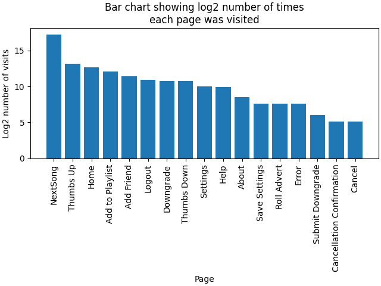

```python
# Plot log base 2 of the page visits for easier comparison
fig, ax = plt.subplots(constrained_layout=True)
ax.bar(page_visits['page'], np.log2(page_visits['count']))
ax.set_title('Bar chart showing log2 number of times\neach page was visited')
ax.set_xlabel('Page')
ax.tick_params(axis='x', labelrotation=90)
ax.set_ylabel('Log2 number of visits');
%matplot plt
```

'Next Song' is by far the most visited page. We note that 'Roll Advert' is visited even by paid users. It's also interesting to see that the 'Downgrade' page is visited far more often than 'Submit Downgrade', indicating a successful retention mechanism at play. The same is not true for cancellations, however.

It will be worth including the 'Downgrade' page visits (minus 'Submit Downgrade' visits) as a feature, as this will indicate previous inclination to churn.

We will count how many times users visited the following pages as features for the model:

- 'About'
- 'Add Friend'
- 'Add to Playlist'
- 'Downgrade' minus 'Submit Downgrade'
- 'Error'
- 'Help'
- 'NextSong'
- 'Roll Advert'
- 'Save Settings'
- 'Thumbs Up'
- 'Thumbs Down'

We count and plot the number of song plays by users.

```python
def play_counts_by_user(df):
    """Count plays, aggregated by user.

    Args:
    df: pyspark dataframe. Events dataframe.

    Returns:
    df: pyspark dataframe: Play counts, aggregated by user.
    """

    df = df.filter(df.page == 'NextSong') \
           .groupBy('userId') \
           .agg(F.count('page').alias('play_count'))

    return df
```

```python
play_counts = play_counts_by_user(explore_df).select('play_count').toPandas()
```

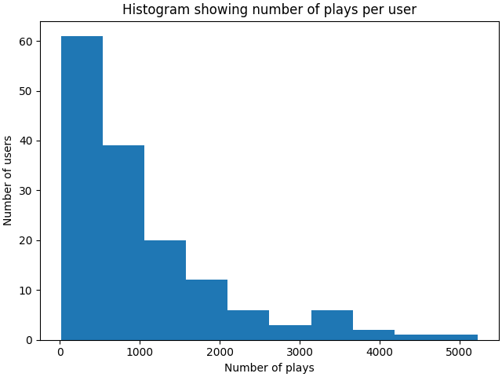

```python
fig, ax = plt.subplots(constrained_layout=True)
ax.hist(play_counts, 10)
ax.set_title("Histogram showing number of plays per user")
ax.set_xlabel('Number of plays')
ax.set_ylabel('Number of users');
%matplot plt
```

It's clear that some users have played many more songs than others.

```python
pages = ['About',
         'Add Friend',
         'Add to Playlist',
         'Downgrade',
         'Submit Downgrade',
         'Error',
         'Help',
         'NextSong',
         'Roll Advert',
         'Save Settings',
         'Thumbs Up',
         'Thumbs Down']
```

We calculate the difference between 'Thumbs Up' and 'Thumbs Down' visits as a proportion of their sum, to get an indication of whether users liked what they were hearing or not overall.

```python
def page_counts_by_user(df):
    """Count visits to pages of interest, aggregated by user.

    Args:
    df: pyspark dataframe: Events dataframe.
    pages: list. The pages of interest.

    Returns:
    df: pyspark dataframe. Page counts, aggregated by user.
    """

    # Count visits to each page per user
    df = df.filter(df.page.isin(pages)) \
                     .groupBy('userId') \
                     .pivot('page').count().fillna(0)

    # Rename columns for ease.
    colnames = [c.lower().replace(" ", "_") if c != 'userId' else c for c in df.columns]
    df = df.toDF(*colnames)

    # Subtract submit_downgrade from downgrade, and drop submit_downgrade
    df = df.withColumn('downgrade', df.downgrade - df.submit_downgrade) \
           .drop('submit_downgrade')

    return df
```

```python
def thumbs_diff_prop_by_user(df):
    """Calculate the differences between Thumbs Up' and 'Thumbs Down' visits as a proportion of the sum, aggregated by user.

    Args:
    df: pyspark dataframe: Events dataframe.

    Returns:
    df: pyspark dataframe. Differences between Thumbs Up' and 'Thumbs Down' visits as a proportion of the sum, aggregated by user.
    """

    df = page_counts_by_user(df)

    df = df.withColumn('thumbs_diff_prop', (df.thumbs_up - df.thumbs_down) / (df.thumbs_up + df.thumbs_down)) \
           .select('userId', 'thumbs_diff_prop') \
           .fillna(0)

    return df
```

```python
thumbs_diff_props = thumbs_diff_prop_by_user(explore_df).select('thumbs_diff_prop').toPandas()
```

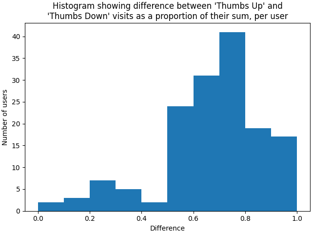

```python
fig, ax = plt.subplots(constrained_layout=True)
ax.hist(thumbs_diff_props, 10)
ax.set_title("Histogram showing difference between 'Thumbs Up' and\n'Thumbs Down' visits as a proportion of their sum, per user")
ax.set_xlabel('Difference')
ax.set_ylabel('Number of users');
%matplot plt
```

The users like more than they dislike, but the extent of this is quite varied.

We will include this measure as a feature for the model.

We check how many users churned.

```python
def churn_by_user(df):
    """Churn or not, by user.

    Args:
    df: pyspark dataframe. Events dataframe.

    Returns:
    df: pyspark dataframe. Churn or not, by user.
    """

    is_churn = F.udf(lambda x: 1 if x == 'Cancellation Confirmation' or  x == 'Submit Downgrade' \
                                 else 0, IntegerType())

    df = df.withColumn('churn', is_churn(df.page)) \
           .groupBy('userId') \
           .agg(F.max('churn').alias('label')) \
           .select('userId', 'label')

    return df
```

```python
churn = churn_by_user(explore_df).select('label').toPandas().value_counts()
```

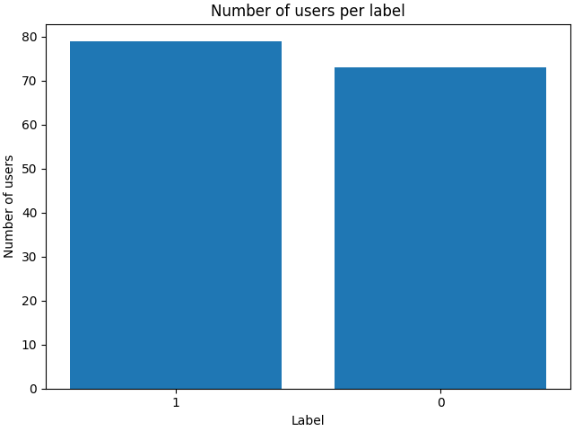

```python
fig, ax = plt.subplots(constrained_layout=True)
ax.bar([str(x[0]) for x in churn.index], churn)
ax.set_title('Number of users per label')
ax.set_xlabel('Label')
ax.set_ylabel('Number of users');
%matplot plt
```

The data is close to balanced.

### artist

We count and plot how many artists paid users listened to.

```python
def counts_by_user(df, col):
    """Count artists or songs played, aggregated by user.

    Args:
    df: pyspark dataframe. Events dataframe.
    col: string. 'artist' or 'song'

    Returns:
    df: pyspark dataframe. Artist or song counts, aggregated by user.
    """

    df = df.filter(df.page == 'NextSong') \
           .groupBy('userId') \
           .agg(F.countDistinct(col).alias(f'{col}_count')) \
           .select('userId', f'{col}_count')

    return df
```

```python
artist_counts = counts_by_user(explore_df, 'artist').select('artist_count').toPandas()
```

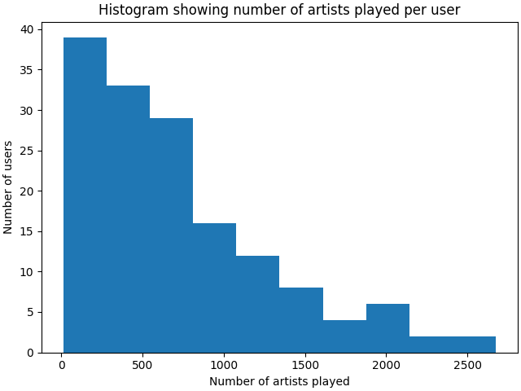

```python
fig, ax = plt.subplots(constrained_layout=True)
ax.hist(artist_counts, 10)
ax.set_title('Histogram showing number of artists played per user')
ax.set_xlabel('Number of artists played')
ax.set_ylabel('Number of users');
%matplot plt
```

We calculate what minimum proportion of artists played by a user accounted for 25% and 50% of their song plays.

```python
def prop_in_top_percent_by_user(df, col, percent):
    """Calculate what minimum proportion of artists or songs played account for percent% of the song plays, aggregated by user.

    Args:
    df: pyspark dataframe. Events dataframe.
    col: string. 'artist' or 'song'
    percent: int. Percent to calculate for.

    Returns:
    df: pyspark dataframe. Proportion of artists or songs played which account for percent% of the song plays, per user.
    """

    # Get artist count per user
    counts_by_user_df = counts_by_user(df, col)

    # Count number of times each user plays each artist
    df = df.filter(df.page == 'NextSong') \
           .groupBy('userId', col) \
           .count()

    # Set up unbounded user window
    user_window = Window.partitionBy('userId')

    # Calculate sum of song plays per user
    df = df.withColumn('total_count', F.sum('count').over(user_window))

    # Set up ordered user window, sort by descending artist popularity, and
    # artist name (to prevent ties in aggregate function)
    user_window = Window.partitionBy('userId').orderBy(F.desc('count'), col)

    # Calculate cumul sum of song plays per user
    df = df.withColumn('cumul_count', F.sum('count').over(user_window))

    # Flag which artists take song plays over percent% of total
    df = df.withColumn('under', (df.cumul_count < (df.total_count * percent / 100)).cast('integer'))

    # Count unflagged artists per user
    df = df.groupBy('userId') \
           .agg(F.sum('under').alias(f'{col}_count_{percent}pc'))

    # Add 1, for the artist that straddles the % boundary
    df = df.withColumn(f'{col}_count_{percent}pc', df[f'{col}_count_{percent}pc'] + 1)

    # Calculate this as a proportion of all artists listened to
    df = df.join(counts_by_user_df, 'userId')
    df = df.withColumn(f'{col}_prop_{percent}pc', df[f'{col}_count_{percent}pc'] / df[f'{col}_count']) \
           .select('userId', f'{col}_prop_{percent}pc')

    return df
```

```python
prop_artists_in_top_25_percent = prop_in_top_percent_by_user(explore_df, 'artist', 25).select('artist_prop_25pc').toPandas()
```

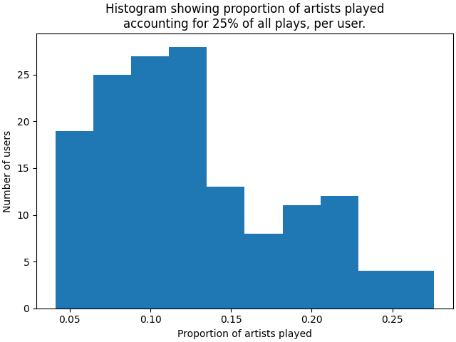

```python
fig, ax = plt.subplots(constrained_layout=True)
ax.hist(prop_artists_in_top_25_percent, 10)
ax.set_title('Histogram showing proportion of artists played\naccounting for 25% of all plays, per user.')
ax.set_xlabel('Proportion of artists played')
ax.set_ylabel('Number of users');
%matplot plt
```

Here, a lower proportion indicates that 25% of the user's song plays are by concentrated among fewer of the artists they've played. A proportion of 0.25 indicates that every song played was by a different artist.

```python
prop_artists_in_top_50_percent = prop_in_top_percent_by_user(explore_df, 'artist', 50).select('artist_prop_50pc').toPandas()
```

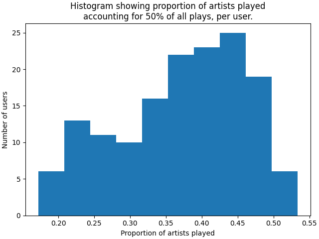

```python
fig, ax = plt.subplots(constrained_layout=True)
ax.hist(prop_artists_in_top_50_percent, 10)
ax.set_title('Histogram showing proportion of artists played\naccounting for 50% of all plays, per user.')
ax.set_xlabel('Proportion of artists played')
ax.set_ylabel('Number of users');
%matplot plt
```

The distribution for 50% of song plays is quite different to that for 25%.

We will count how many artists each user played, and calculate what proportion of these accounted for 25% and 50% of their song plays, and include these as features for the model, to distinguish between users who stick to relatively few artists and those who listen to a broad range of artists.

We explore how song plays are distributed among artists. Here we analyse `events_df` rather than `explore_df` for a complete picture.

First we calculate what proportion of paid song plays is represented when only including the top x artists ranked by popularity. This gives us an idea of how many artists we could potentially include as features.

```python
# Count the number of times each artist was played, sort and send to pandas for easier manipulation/visualisation
artist_play_stats = events_df.filter((events_df.page == 'NextSong') & (events_df.level == 'paid')) \
                             .groupBy('artist') \
                             .count() \
                             .orderBy('count', ascending=False) \
                             .toPandas()

# Store number of artists for later
n_artists = len(artist_play_stats)

# Calculate total number of songs played
play_count = artist_play_stats['count'].sum()

# Calculate proportion of total songs for each artist
artist_play_stats['prop'] = artist_play_stats['count'] / play_count

# Calculate cumulative proportion of total songs for each artist in rank order
artist_play_stats['cumul_prop'] = np.cumsum(artist_play_stats['prop'])
```

We plot the cumulative proportion.

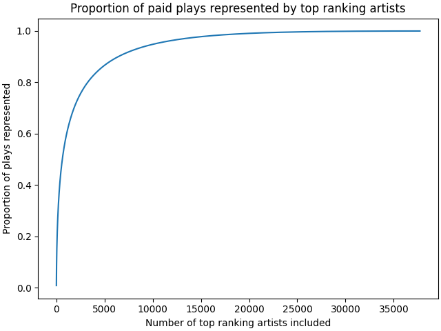

```python
fig, ax = plt.subplots(constrained_layout=True)
ax.plot(artist_play_stats['cumul_prop'])
ax.set_title('Proportion of paid plays represented by top ranking artists')
ax.set_xlabel('Number of top ranking artists included')
ax.set_ylabel('Proportion of plays represented');
%matplot plt
```

We zoom in on the top 1000 artists.

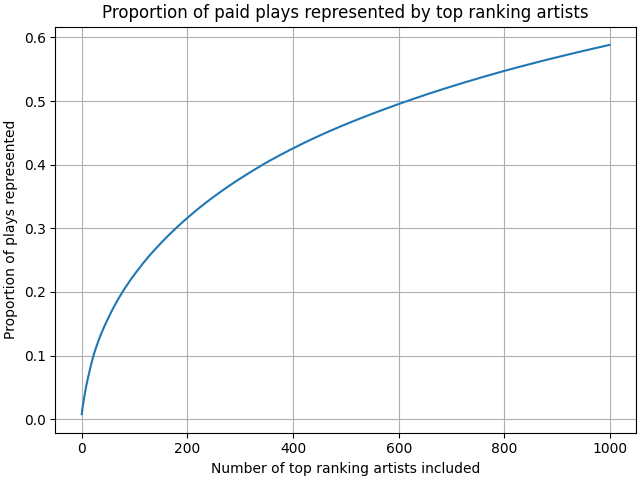

```python
top_artist_play_stats = artist_play_stats[:1000]
fig, ax = plt.subplots(constrained_layout=True)
ax.plot(top_artist_play_stats['cumul_prop'])
ax.set_title('Proportion of paid plays represented by top ranking artists')
ax.set_xlabel('Number of top ranking artists included')
ax.set_ylabel('Proportion of plays represented')
ax.grid(); # visual aid
%matplot plt
```

Including the top 1000 artists would cover over 50% of the song plays.

We look at how many song plays the top 1000 artists each account for.

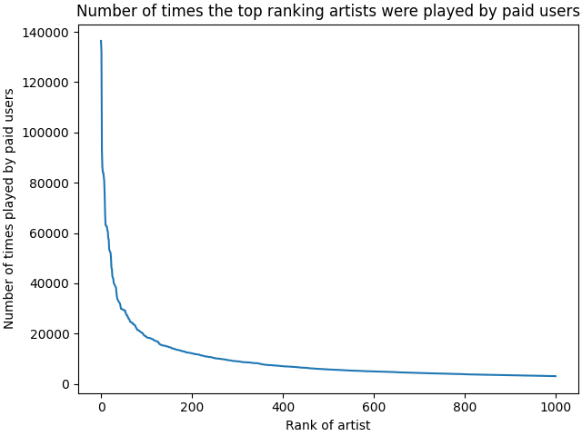

```python
fig, ax = plt.subplots(constrained_layout=True)
ax.plot(top_artist_play_stats['count'])
ax.set_title('Number of times the top ranking artists were played by paid users')
ax.set_xlabel('Rank of artist')
ax.set_ylabel('Number of times played by paid users');
%matplot plt
```

We could potentially include some features to describe users' artist preferences. While the artists themselves are unlikely to directly influence churn, the mix of artists listened to may be indicative of other factors which are influential.

We calculate the proportion of users' songs played which were performed by each of the 1000 most popular artists. A principle component analysis may enable us to roughly distinguish between users' artist preferences using a handful of of features.

```python
def get_top_artists_list(df, n_artists):
    """Gets a list of the top n_artists artists by number of plays.

    Args:
    df: pyspark dataframe. Event data.
    n_artists: int. The number of artists to include.

    Returns:
    top_artists_list: list. The top artists in descending order.
    """

    # Establish top artists in descending order of song plays
    artist_play_count = df.filter(df.artist != 'None') \
                          .groupBy('artist') \
                          .count() \
                          .orderBy('count', ascending=False) \
                          .limit(n_artists) \
                          .toPandas()

    # Store top artist names in list
    top_artists_list = artist_play_count.artist.tolist()

    return top_artists_list
```

```python
def top_artists_play_prop_per_user(df, n):
    """Calculate the proportion of plays by each of the top artists, aggregated by user.

    Args:
    df: pyspark dataframe. Events dataframe.
    n: numeric: number to pass to get_top_artists

    Returns:
    df: pyspark dataframe. Proportion of plays by each of the top artists, aggregated by user.
    artist_decode_dict: dict. key: column name, value: artist name.
    """

    # Get list of top artists
    top_artists_list = sc.broadcast(get_top_artists_list(df, n))

    # Get total plays per user
    play_counts_by_user_df = play_counts_by_user(df)

    # Create shortcodes to use as column names for artist features, store in dictionary keyed by artist name
    artist_encode_dict = {artist_name:f'A{i}' for (i, artist_name) in enumerate(top_artists_list.value)}
    other_artist_code = f'A{len(top_artists_list.value)}' # for anyone not in top_artists_list

    # Store artist names in dictionary keyed by column name (shortcode)
    artist_decode_dict = {f'A{i}':artist_name for (i, artist_name) in enumerate(top_artists_list.value)}
    artist_decode_dict[other_artist_code] = 'Other artist' # catches anyone not in top_artists_list

    # Retain user id and artist name for each play, overwrite artist name with code
    encode_artist = F.udf(lambda x: artist_encode_dict[x] if x in artist_encode_dict else other_artist_code, StringType())

    df = df.select('artist', 'userId').filter(df.artist != 'None') \
                                      .withColumn('artist', encode_artist(df.artist))

    # Pivot to count plays per user for each artist
    df = df.groupBy('userId').pivot('artist').count().fillna(0)

    # Join total plays per user
    df = df.join(play_counts_by_user_df, 'userId')

    # Convert artist play counts to proportions of total plays per user
    artist_colnames = list(artist_decode_dict.keys())
    df = df.select('userId', *[(df[c] / df['play_count']).alias(c) for c in artist_colnames])

    return df, artist_decode_dict
```

```python
artist_df, artist_decode_dict = top_artists_play_prop_per_user(events_df.filter(events_df.level == 'paid'), 1000)
artist_df = artist_df.persist(StorageLevel.MEMORY_ONLY)
```

We vectorize and standardize the artist proportions.

```python
def vectorize_standardize_features(df):
    """Vectorize features and remove individual feature columns.

    Args:
    df: pyspark dataframe. Features, by user.

    Returns:
    df: pyspark dataframe. Vectorized features, by user.
    """

    # Vectorize features
    feature_cols = [c for c in df.columns if c not in ['userId', 'label']]

    assembler = VectorAssembler(inputCols=feature_cols, outputCol='raw_features')
    df = assembler.transform(df)
    df = df.drop(*feature_cols)

    # Standardize features
    scaler = StandardScaler(inputCol='raw_features', outputCol='features',
                            withStd=True, withMean=True)

    scaler_model = scaler.fit(df)
    df = scaler_model.transform(df)
    df = df.drop('raw_features')

    return df
```

```python
vs_artist_df = vectorize_standardize_features(artist_df).persist(StorageLevel.MEMORY_ONLY)
```

We run the principal component analysis.

```python
pca = PCA(k=200, inputCol="features", outputCol="components")
pca_model = pca.fit(vs_artist_df)
```

We plot the explained variance for the principal components.

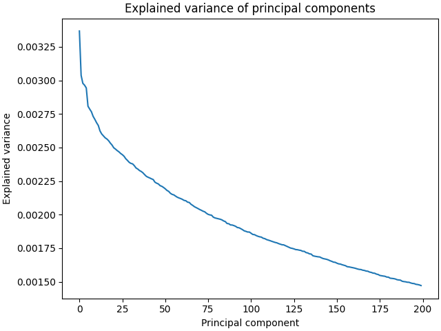

```python
fig, ax = plt.subplots(constrained_layout=True)
ax.plot(pca_model.explainedVariance)
ax.set_title('Explained variance of principal components')
ax.set_xlabel('Principal component')
ax.set_ylabel('Explained variance');
%matplot plt
```

The principal components explain very little variance. We would need more than a handful of principal components to distinguish between users' preferred artists.

We plot the cumulative explained variance.

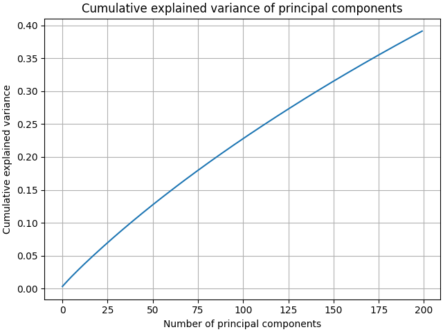

```python
# Calculate cumulative explained variance
cumul_explained_variance = np.cumsum(pca_model.explainedVariance)

# Plot
fig, ax = plt.subplots(constrained_layout=True)
ax.plot(cumul_explained_variance)
ax.set_title('Cumulative explained variance of principal components')
ax.set_xlabel('Number of principal components')
ax.set_ylabel('Cumulative explained variance')
ax.grid(); # visual aid
%matplot plt
```

It seems the users' listening habits in terms of artists are so varied and individual that there is little to be gained through a principal component analysis for dimension reduction.

N.B. Outside of this notebook, 100 features were engineered based on the users' listening habits in terms of artists, using UnivariateFeatureSelector to select the most relevant artists, but they increased the execution quite dramatically with little, if anything, to show for it in terms of improved validation score, so they were ultimately not included.

```python
artist_df.unpersist()
vs_artist_df.unpersist()
```

```
DataFrame[userId: string, features: vector]
```

### gender

We count and plot the number of males and females amongst paid users.

```python
# Count number of users for each gender, and send to pandas for easier visualisation
gender_count = explore_df.groupBy('gender') \
                         .agg(F.countDistinct('userId').alias('count')) \
                         .toPandas()
```

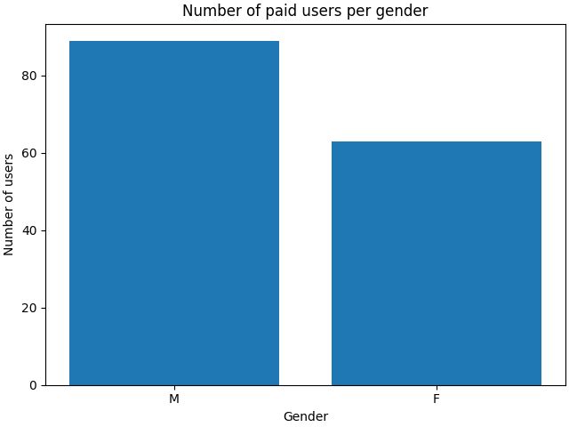

```python
fig, ax = plt.subplots(constrained_layout=True)
ax.bar(gender_count['gender'], gender_count['count'])
ax.set_title('Number of paid users per gender')
ax.set_xlabel('Gender')
ax.set_ylabel('Number of users');
%matplot plt
```

```python
def male_by_user(df):
    """Male or not, by user.

    Args:
    df: pyspark dataframe. Events dataframe.

    Returns:
    df: pyspark dataframe. Male or not, by user.
    """

    # Encode gender as male 1, female 0
    df = df.groupBy('userId', 'gender') \
           .count() \
           .withColumn('male', (df.gender == 'M').cast(IntegerType())) \
           .select('userId', 'male')

    return df
```

### itemInSession

Whilst useful-sounding, this number includes all events - we will instead calculate the average number of song plays per session for each user, using sessionId.

### length

We will use this column, which refers to the song length in seconds, in conjunction with `ts` to calculate users' proportion of songs that were skipped before reaching their halfway point. This will give us another measure of whether users liked what they were hearing.

### location

We count the number of locations in events_df to make sure we have the full number of potential features.

```python
events_df.filter(events_df.level == 'paid').agg(F.countDistinct('location')).collect()[0][0]
```

```
858
```

We check some examples.

```python
events_df.filter(events_df.level == 'paid').select('location').distinct().show(10, False)
```

```
+---------------------------+
|location                   |
+---------------------------+
|San Diego-Carlsbad, CA     |
|Searcy, AR                 |
|Mobile, AL                 |
|Charleston-Mattoon, IL     |
|Atlantic City-Hammonton, NJ|
|Birmingham-Hoover, AL      |
|Seattle-Tacoma-Bellevue, WA|
|Topeka, KS                 |
|Owatonna, MN               |
|Dayton, OH                 |
+---------------------------+
only showing top 10 rows
```

One-hot-encoding this column would add a lot of features to the model. We will leave this for now, but could consider adding these features depending on model execution time.

### registration

We check the format of this timestamp.

```python
registration = explore_df.select('registration').collect()[0][0]

# Try converting timestamp divided by 1000 to datetime
datetime.datetime.fromtimestamp(registration / 1000)
```

```
datetime.datetime(2018, 9, 13, 1, 33, 35)
```

The timestamp is measuring milliseconds.

We check the time period over which users registered.

```python
# Get earliest and latest timestamps
first = explore_df.agg(F.min('registration')).collect()[0][0]
last = explore_df.agg(F.max('registration')).collect()[0][0]

# Convert to datetimes
first = datetime.datetime.fromtimestamp(first / 1000)
last = datetime.datetime.fromtimestamp(last / 1000)
print(f'First registration: {first}\nLast registration: {last}')
```

```
First registration: 2018-03-08 10:48:42
Last registration: 2018-11-30 09:07:08
```

The registrations cover a period of 8 months. We will include the registration timestamp as a feature.

```python
def registrations_by_user(df):
    """Registration timestamp, by user.

    Args:
    df: pyspark dataframe. Events dataframe.

    Returns:
    df: pyspark dataframe. Registration timestamp (numerical), by user.
    """

    # Encode gender as male 1, female 0
    df = df.groupBy('userId', 'registration') \
           .count() \
           .withColumn('registration', (df.registration).cast(LongType())) \
           .select('userId', 'registration')

    return df
```

### sessionId

We count the number of sessions per user.

```python
def sessions_by_user(df):
    """Count sessions, aggregated by user.

    Args:
    df: pyspark dataframe. Events dataframe.

    Returns:
    df: pyspark dataframe. Count of sessions, aggregated by user.
    """

    df = df.select('userId', 'sessionId') \
           .groupBy('userId') \
           .agg(F.countDistinct("sessionId").alias('sessions_count'))

    return df
```

```python
sessions = sessions_by_user(explore_df).select('sessions_count').toPandas()
```

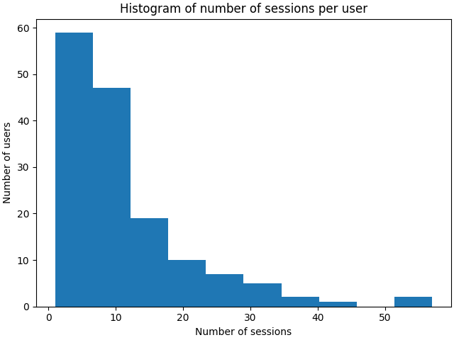

```python
fig, ax = plt.subplots(constrained_layout=True)
ax.hist(sessions, 10)
ax.set_title('Histogram of number of sessions per user')
ax.set_xlabel('Number of sessions')
ax.set_ylabel('Number of users');
%matplot plt
```

Some users listened over many more sessions than others.

We will include the number of sessions per user as a feature for the model.

We calculate users' average number of songs played per session.

```python
def songs_per_session_by_user(df):
    """ Mean songs per session, aggregated by user.

    Args:
    df: pyspark dataframe. Events dataframe.

    Returns:
    df: pyspark dataframe. Mean of songs per session, aggregated by user.
    """

    df = df.filter(df.page == 'NextSong') \
           .groupBy('userId', 'sessionId') \
           .count() \
           .groupBy('userId') \
            .agg(F.mean('count').alias('songs_per_session'))

    return df
```

```python
songs_per_session = songs_per_session_by_user(explore_df).select('songs_per_session').toPandas()
```

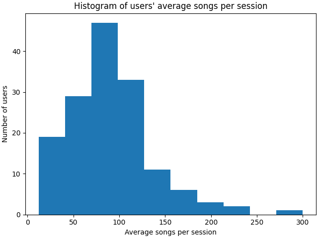

```python
fig, ax = plt.subplots(constrained_layout=True)
ax.hist(songs_per_session, 10)
ax.set_title("Histogram of users' average songs per session")
ax.set_xlabel('Average songs per session')
ax.set_ylabel('Number of users');
%matplot plt
```

Some users play far more songs per session than others. We will include users' average songs per session as a feature for the model.

### songs

We count and plot how many songs paid users listened to.

```python
song_counts = counts_by_user(explore_df, 'song').select('song_count').toPandas()
```

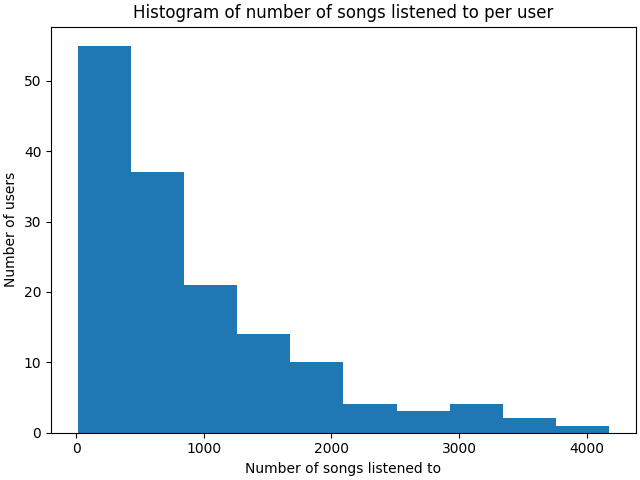

```python
fig, ax = plt.subplots(constrained_layout=True)
ax.hist(song_counts, 10)
ax.set_title('Histogram of number of songs listened to per user')
ax.set_xlabel('Number of songs listened to')
ax.set_ylabel('Number of users');
%matplot plt
```

We calculate what minimum proportion of songs played by a user accounted for 25% and 50% of their song plays.

```python
prop_songs_in_top_25_percent = prop_in_top_percent_by_user(explore_df, 'song', 25).select('song_prop_25pc').toPandas()
```

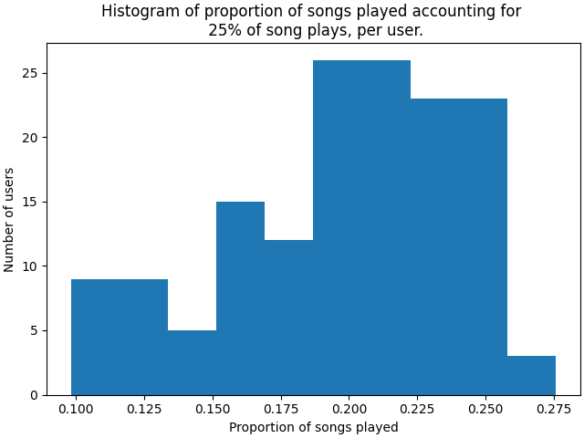

```python
fig, ax = plt.subplots(constrained_layout=True)
ax.hist(prop_songs_in_top_25_percent, 10)
ax.set_title('Histogram of proportion of songs played accounting for \n 25% of song plays, per user.')
ax.set_xlabel('Proportion of songs played')
ax.set_ylabel('Number of users');
%matplot plt
```

```python
prop_songs_in_top_50_percent = prop_in_top_percent_by_user(explore_df, 'song', 50).select('song_prop_50pc').toPandas()
```

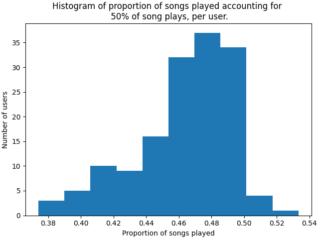

```python
fig, ax = plt.subplots(constrained_layout=True)
ax.hist(prop_songs_in_top_50_percent, 10)
ax.set_title('Histogram of proportion of songs played accounting for \n 50% of song plays, per user.')
ax.set_xlabel('Proportion of songs played')
ax.set_ylabel('Number of users');
%matplot plt
```

We will count how many songs each user played, and calculate what proportion of these accounted for 25% and 50% of their song plays, and include these as features for the model, to distinguish between users who stick to relatively few songs and those who listen to a broad range of artists.

### ts

We check the format of the timestamp is the same as registration.

```python
timestamp = explore_df.select('ts').collect()[0][0]

# Try converting timestamp divided by 1000 to datetime
datetime.datetime.fromtimestamp(timestamp / 1000)
```

```
datetime.datetime(2018, 10, 16, 5, 29, 19)
```

The timestamp is measuring milliseconds.

We check the time period covered by the dataset.

```python
# Get earliest and latest timestamps
first = explore_df.agg(F.min('ts')).collect()[0][0]
last = explore_df.agg(F.max('ts')).collect()[0][0]

# Convert to datetimes
first_dt = datetime.datetime.fromtimestamp(first / 1000)
last_dt = datetime.datetime.fromtimestamp(last / 1000)
print(f'First event: {first_dt}\nLast event: {last_dt}')
```

```
First event: 2018-10-01 00:00:32
Last event: 2018-11-30 23:59:47
```

The data covers a two month period.

We calculate the proportion of the song actually played for each play and plot the distribution.

```python
def prop_song_played_by_play(df):
    """Calculate the proportion of each song that is actually played for each play.

    Args:
    df: pyspark dataframe. Events dataframe.

    Returns:
    df: pyspark dataframe. Proportion of song actually played for each song play event, and userId.
    """

    # Set up a user window ordered by timestamp
    userWindow  = Window.partitionBy('userId').orderBy('ts')

    # Add the next event's timestamp to each event
    df = df.withColumn('next_ts', F.lead('ts', default=last).over(userWindow))

    # Calculate the amount of time before next event occurs
    df = df.withColumn('seconds_spent', ((df.next_ts.cast(LongType()) - df.ts.cast(LongType())) / 1000))

    # Calculate the proportion of each song that was played
    df = df.filter(df.page == 'NextSong') \
           .withColumn('prop_song_played', F.least(F.lit(1), (df.seconds_spent.cast(IntegerType()) / df.length.cast(IntegerType())))) \
           .select('userId', 'prop_song_played')

    return df
```

```python
prop_songs_played = prop_song_played_by_play(explore_df).select('prop_song_played').toPandas()
```

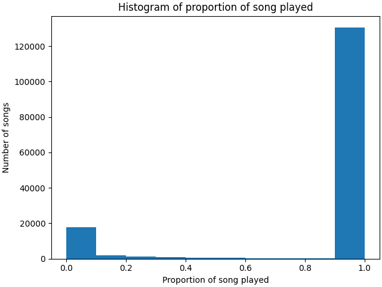

```python
fig, ax = plt.subplots(constrained_layout=True)
ax.hist(prop_songs_played, [x/10 for x in range(0,11)])
ax.set_title('Histogram of proportion of song played')
ax.set_xlabel('Proportion of song played')
ax.set_ylabel('Number of songs');
%matplot plt
```

We can verify that songs are not always listened to in full.

We calculate the proportion of songs skipped before the halfway point per user.

```python
def avg_prop_song_played_by_user(df):
    """Calculate the proportion of songs skipped before the halfway point per user.

    Args:
    df: pyspark dataframe. Proportion of song actually played for each song play event, and userId.

    Returns:
    df: pyspark dataframe. Proportion of songs skipped before the halfway point per user.
    """

    # Get proportion of each song played
    df = prop_song_played_by_play(df)

    # Flag which were skipped before halfway point
    df = df.withColumn('played_under_half', (df.prop_song_played < 0.5).cast('integer')) \
           .select('userId', 'played_under_half') \
           .groupBy('userId') \
           .agg(F.mean('played_under_half').alias('avg_played_under_half')) \
           .select('userId', 'avg_played_under_half')

    return df
```

```python
avg_prop_song_played = avg_prop_song_played_by_user(explore_df).select('avg_played_under_half').toPandas()
```

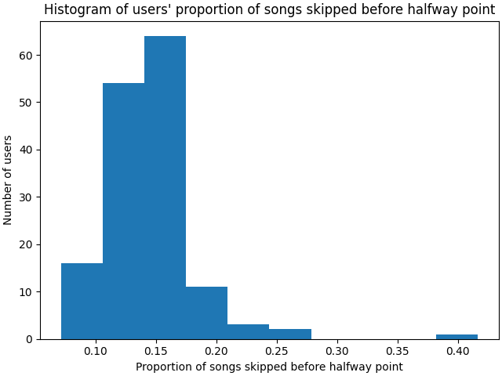

```python
fig, ax = plt.subplots(constrained_layout=True)
ax.hist(avg_prop_song_played, 10)
ax.set_title("Histogram of users' proportion of songs skipped before halfway point")
ax.set_xlabel('Proportion of songs skipped before halfway point')
ax.set_ylabel('Number of users');
%matplot plt
```

Most users skip between a tenth and a fifth of songs before the halfway point.

We will include this proportion as a feature for the model.

### userAgent

We count the number of user agents in events_df to make sure we have the full number of potential features.

```python
events_df.filter(events_df.level == 'paid').agg(F.countDistinct('userAgent')).collect()[0][0]
```

```
85
```

```python
events_df.filter(events_df.level == 'paid').select('userAgent').distinct().show(50, False)
```

```
+-----------------------------------------------------------------------------------------------------------------------------------------------+
|userAgent                                                                                                                                      |
+-----------------------------------------------------------------------------------------------------------------------------------------------+
|Mozilla/5.0 (Windows NT 6.1; WOW64; rv:29.0) Gecko/20100101 Firefox/29.0                                                                       |
|Mozilla/5.0 (Macintosh; Intel Mac OS X 10.9; rv:31.0) Gecko/20100101 Firefox/31.0                                                              |
|Mozilla/5.0 (X11; Ubuntu; Linux i686; rv:31.0) Gecko/20100101 Firefox/31.0                                                                     |
|"Mozilla/5.0 (iPhone; CPU iPhone OS 7_1_2 like Mac OS X) AppleWebKit/537.51.1 (KHTML, like Gecko) GSA/4.1.0.31802 Mobile/11D257 Safari/9537.53"|
|null                                                                                                                                           |
|"Mozilla/5.0 (Windows NT 6.2; WOW64) AppleWebKit/537.36 (KHTML, like Gecko) Chrome/36.0.1985.125 Safari/537.36"                                |
|"Mozilla/5.0 (Macintosh; Intel Mac OS X 10_9_2) AppleWebKit/537.36 (KHTML, like Gecko) Chrome/37.0.2062.94 Safari/537.36"                      |
|"Mozilla/5.0 (Macintosh; Intel Mac OS X 10_6_8) AppleWebKit/537.36 (KHTML, like Gecko) Chrome/36.0.1985.143 Safari/537.36"                     |
|"Mozilla/5.0 (Macintosh; Intel Mac OS X 10_9_2) AppleWebKit/537.75.14 (KHTML, like Gecko) Version/7.0.3 Safari/537.75.14"                      |
|"Mozilla/5.0 (Macintosh; Intel Mac OS X 10_10) AppleWebKit/538.46 (KHTML, like Gecko) Version/8.0 Safari/538.46"                               |
|"Mozilla/5.0 (iPad; CPU OS 7_1_1 like Mac OS X) AppleWebKit/537.51.2 (KHTML, like Gecko) Version/7.0 Mobile/11D201 Safari/9537.53"             |
|"Mozilla/5.0 (Macintosh; Intel Mac OS X 10_10) AppleWebKit/600.1.3 (KHTML, like Gecko) Version/8.0 Safari/600.1.3"                             |
|"Mozilla/5.0 (Macintosh; Intel Mac OS X 10_10_0) AppleWebKit/537.36 (KHTML, like Gecko) Chrome/36.0.1985.125 Safari/537.36"                    |
|"Mozilla/5.0 (Macintosh; Intel Mac OS X 10_9_4) AppleWebKit/537.36 (KHTML, like Gecko) Chrome/37.0.2062.94 Safari/537.36"                      |
|"Mozilla/5.0 (Windows NT 6.1; WOW64) AppleWebKit/537.36 (KHTML, like Gecko) Chrome/37.0.2062.94 Safari/537.36"                                 |
|Mozilla/5.0 (Macintosh; Intel Mac OS X 10.8; rv:31.0) Gecko/20100101 Firefox/31.0                                                              |
|"Mozilla/5.0 (Macintosh; Intel Mac OS X 10_8_5) AppleWebKit/537.36 (KHTML, like Gecko) Chrome/36.0.1985.143 Safari/537.36"                     |
|Mozilla/5.0 (compatible; MSIE 9.0; Windows NT 6.1; WOW64; Trident/5.0)                                                                         |
|Mozilla/5.0 (Windows NT 6.1; WOW64; rv:31.0) Gecko/20100101 Firefox/31.0                                                                       |
|Mozilla/5.0 (Macintosh; Intel Mac OS X 10.9; rv:30.0) Gecko/20100101 Firefox/30.0                                                              |
|"Mozilla/5.0 (Macintosh; Intel Mac OS X 10_8_5) AppleWebKit/537.77.4 (KHTML, like Gecko) Version/6.1.5 Safari/537.77.4"                        |
|"Mozilla/5.0 (Windows NT 5.1) AppleWebKit/537.36 (KHTML, like Gecko) Chrome/36.0.1985.125 Safari/537.36"                                       |
|"Mozilla/5.0 (Macintosh; Intel Mac OS X 10_8_5) AppleWebKit/537.36 (KHTML, like Gecko) Chrome/37.0.2062.94 Safari/537.36"                      |
|"Mozilla/5.0 (Windows NT 6.3; WOW64) AppleWebKit/537.36 (KHTML, like Gecko) Chrome/37.0.2062.94 Safari/537.36"                                 |
|Mozilla/5.0 (compatible; MSIE 9.0; Windows NT 6.1; Trident/5.0)                                                                                |
|"Mozilla/5.0 (Macintosh; Intel Mac OS X 10_9_4) AppleWebKit/537.36 (KHTML, like Gecko) Chrome/36.0.1985.143 Safari/537.36"                     |
|"Mozilla/5.0 (Macintosh; Intel Mac OS X 10_7_5) AppleWebKit/537.36 (KHTML, like Gecko) Chrome/36.0.1985.125 Safari/537.36"                     |
|Mozilla/5.0 (Windows NT 6.0; rv:31.0) Gecko/20100101 Firefox/31.0                                                                              |
|Mozilla/5.0 (Macintosh; Intel Mac OS X 10.6; rv:31.0) Gecko/20100101 Firefox/31.0                                                              |
|"Mozilla/5.0 (Macintosh; Intel Mac OS X 10_6_8) AppleWebKit/534.59.10 (KHTML, like Gecko) Version/5.1.9 Safari/534.59.10"                      |
|"Mozilla/5.0 (Windows NT 6.2; WOW64) AppleWebKit/537.36 (KHTML, like Gecko) Chrome/36.0.1985.143 Safari/537.36"                                |
|Mozilla/5.0 (X11; Linux x86_64; rv:31.0) Gecko/20100101 Firefox/31.0                                                                           |
|"Mozilla/5.0 (Windows NT 6.1; WOW64) AppleWebKit/537.36 (KHTML, like Gecko) Chrome/35.0.1916.153 Safari/537.36"                                |
```

[output cut: 19 more lines]

One-hot-encoding this column would add a lot of features to the model. We will leave this for now, but could consider adding these features depending on model execution time.

```python
explore_df.unpersist()
```

```
DataFrame[userId: string, artist: string, auth: string, firstName: string, gender: string, itemInSession: bigint, lastName: string, length: double, level: string, location: string, method: string, page: string, registration: bigint, sessionId: bigint, song: string, status: bigint, ts: bigint, userAg…
```

## Data Cleaning

We will need to remove rows for users that are logged out or guests, as by definition they cannot churn.

We will also repartition the data by user as we will regularly be joining on this column.

```python
def clean_data(df):
    """Remove rows for users who are logged out or guests, remove unneeded columns,
       and drop any remaining rows with missing data other than artist.

    Args:
    df: pyspark dataframe. The df to be cleaned

    Returns:
    df: pyspark dataframe. The cleaned df
    """

    # Retain rows for paid, logged-in/cancelling users
    df = df[(df['level'] == 'paid') & ((df['auth'] == 'Logged In') | (df['auth'] == 'Cancelled'))]

    # Drop unnecessary columns
    df = df.drop('level', 'auth', 'firstName', 'itemInSession', 'lastName', 'location', 'method', 'status', 'userAgent')

    # Drop rows with missing data in key columns
    missing_allowed = ['artist', 'length', 'song']
    df = df.dropna(subset=[c for c in df.columns if c not in missing_allowed])

    # Repartition by user
    df = df.repartition(partitions, 'userId').sortWithinPartitions('artist')

    return df
```

```python
clean_df = clean_data(events_df).persist(StorageLevel.MEMORY_ONLY)
```

We check the number of users in the clean data.

```python
clean_df.agg(F.countDistinct('userID')).show()
```

```
+-------------+
|count(userID)|
+-------------+
|        16184|
+-------------+
```

```python
events_df.unpersist()
```

```
DataFrame[artist: string, auth: string, firstName: string, gender: string, itemInSession: bigint, lastName: string, length: double, level: string, location: string, method: string, page: string, registration: bigint, sessionId: bigint, song: string, status: bigint, ts: bigint, userAgent: string, use…
```

## Feature Engineering

We will aggregate and analyse the data by user.

Our features at this stage will incorporate, per user:

- total number visits to the following pages
  - 'About'
  - 'Add Friend'
  - 'Add to Playlist'
  - 'Downgrade' minus 'Submit Downgrade'
  - 'Error'
  - 'Help'
  - 'NextSong'
  - 'Roll Advert'
  - 'Save Settings'
  - 'Thumbs Up'
  - 'Thumbs Down'
- difference between visits to 'Thumbs Up' and 'Thumbs Down' as a proportion of their sum
- number of artists played, and the proportion of these that accounted for 25% of song plays and 50% of song plays
- number of songs played, and the proportion of these that accounted for 25% of song plays and 50% of song plays
- gender
- registration timestamp
- number of sessions
- average songs per session
- proportion of song plays skipped before halfway point

There will also be a binary label to indicate whether or not the user churned.

We engineer the features.

```python
def engineer_features(df):
    """Aggregates events dataframe into users dataframe containing features needed for analysis

    Args:
    df: pyspark df. Events dataframe.

    Returns:
    df: pyspark df. Users dataframe.
    feat_names: list. Feature names in order.
    """

    df = churn_by_user(df).join(page_counts_by_user(df), 'userId') \
                          .join(thumbs_diff_prop_by_user(df), 'userId') \
                          .join(counts_by_user(df, 'artist'), 'userId') \
                          .join(prop_in_top_percent_by_user(df, 'artist', 50), 'userId') \
                          .join(prop_in_top_percent_by_user(df, 'artist', 25), 'userId') \
                          .join(counts_by_user(df, 'song'), 'userId') \
                          .join(prop_in_top_percent_by_user(df, 'song', 50), 'userId') \
                          .join(prop_in_top_percent_by_user(df, 'song', 25), 'userId') \
                          .join(male_by_user(df), 'userId') \
                          .join(registrations_by_user(df), 'userId') \
                          .join(sessions_by_user(df), 'userId') \
                          .join(songs_per_session_by_user(df), 'userId') \
                          .join(avg_prop_song_played_by_user(df), 'userId')

    feat_names = df.columns[2:]

    df = vectorize_standardize_features(df)

    return df, feat_names
```

```python
feat_df, feat_names = engineer_features(clean_df)
```

## Data Balancing

We could balance the full dataset through undersampling (as the full dataset is very large), and the sample dataset through oversampling (as the sample dataset is much smaller). However the data is close enough to being balanced already that we skip this step.

```python
def balance_dataset(df, oversample=False, seed=None):
    """Balances dataset via undersampling or oversampling.

    Args:
    df: pyspark df. Unbalanced dataset.
    undersample: boolean. True to oversample, False to undersample (default).
    seed: int. random seed for sampling

    Returns:
    df: pyspark df. Balanced dataset.
    """

    # Split by label into separate dataframes
    major_df = df.filter(df.label == 0)
    minor_df = df.filter(df.label == 1)

    # Calculate ratio
    ratio = major_df.count() / minor_df.count()

    if oversample:
        # Take a sample of the smaller dataset - enough to make up the remainind
        # difference after multiple whole copies of the smaller dataset are combined
        minor_df_sample = minor_df.sample(False, ratio % 1, seed)

        # Add the sample to the larger dataset
        df = minor_df_sample.unionAll(major_df)

        # Add the smaller dataset as many times as needed
        for i in range(0, int(ratio)):
            df = df.unionAll(minor_df)
        print('Data oversampled.')
    else:
        # Take a sample of the larger dataset and combine with the smaller
        major_df = major_df.sample(False, 1/ratio, seed)
        df = major_df.unionAll(minor_df)
        print('Data undersampled.')

    return df
```

```python
# Balance data
# balanced_df = balance_dataset(select_df, sample_data, 42).persist(StorageLevel.DISK_ONLY)
# select_df = select_df.unpersist()
```

## Train/Test Split

We split into train and test sets.

```python
# Split into train and test sets
train_df, test_df = feat_df.randomSplit(weights=[0.8, 0.2], seed=42)
train_df = train_df.persist(StorageLevel.MEMORY_ONLY)
test_df = test_df.persist(StorageLevel.MEMORY_ONLY)
print(f'train set size: {train_df.count()}')
print(f'test set size: {test_df.count()}')
```

```
train set size: 12877
test set size: 3275
```

## Initial Model

We initially train a default logistic regression model and check its metrics to get a baseline F-score.

```python
def display_metrics(pred_df):
    """ Calculates and displays confusion matrix, precision, recall and F-score.

    Args:
    pred_df: pyspark dataframe. Dataframe containing predictions column and labels column.

    Returns:
    precision: float.
    recall: float.
    f_score: float.
    """

    # Calculate confusion matrix
    true_positive = pred_df.filter((pred_df.label == 1) & (pred_df.prediction == 1)).count()
    false_negative = pred_df.filter((pred_df.label == 1) & (pred_df.prediction == 0)).count()
    true_negative = pred_df.filter((pred_df.label == 0) & (pred_df.prediction == 0)).count()
    false_positive = pred_df.filter((pred_df.label == 0) & (pred_df.prediction == 1)).count()

    ## Calculate metrics
    precision = true_positive / (true_positive + false_positive)
    recall = true_positive / (true_positive + false_negative)
    f_score = (2 * precision * recall) / (precision + recall)

    ## Print confusion matrix and metrics
    print(f'       pred\n       T  F\nact  T {true_positive} {false_negative}\n     F {false_positive} {true_negative}\n')
    print(f'Precision: {precision}\nRecall: {recall}\n')
    print(f'F-score: {f_score}')

    return precision, recall, f_score
```

```python
# Fit model on train set
lor = LogisticRegression(maxIter=10, regParam=0.0, elasticNetParam=0.0)
lor_model = lor.fit(train_df)

# Make predictions on test set
pred_df = lor_model.transform(test_df).persist(StorageLevel.MEMORY_ONLY)

# Display metrics
precision, recall, f_score = display_metrics(pred_df)
```

```
       pred
       T  F
act  T 814 758
     F 489 1214

Precision: 0.624712202609363
Recall: 0.5178117048346056

F-score: 0.5662608695652174
```

This model didn't perform particularly well, missing a lot of churns and also predicting a lot of churns which didn't occur.

```python
pred_df.unpersist()
```

```
DataFrame[userId: string, label: int, features: vector, rawPrediction: vector, probability: vector, prediction: double]
```

## Improved Model

### Pipeline

We build a pipeline to compare a logistic regression, a random forest classifier, and a gradient boosted tree classifier, each with five combinations of hyperparameters.

N.B. Rather than a grid search which would entail a great number of combinations of hyperparameters and thus long execution time, we would ideally implement a random search entailing 60 combinations, as suggested by James Bergstra and Yoshua Bengio at https://www.jmlr.org/papers/volume13/bergstra12a/bergstra12a.pdf. Here, we try only five combinations per classifier, for faster execution, and we handpick the parameter values to ensure coverage across the spread of possible values. This isn't really enough combinations to reliably find an model close to the optimum, but a greater number of truly randomised combinations could easily be added for a more thorough search of hyperparameter space.

```python
# Prepare models, pipeline and parameter grid
lors = [LogisticRegression() for i in range(0, 5)]
rfs = [RandomForestClassifier() for i in range(0, 5)]
gbts = [GBTClassifier() for i in range(0, 5)]

lor_stages = []
rf_stages= []
gbt_stages = []

pipeline = Pipeline(stages=[])
param_grid = []

# Specify some combinations for logistic regression parameters
lor_params = [[10, 0, 0], [10, 0.1, 0], [10, 0.1, 0.5],
              [10, 0.1, 1], [100, 0.1, 0.5]]

# Add stages for logistic regression
for i in range(0, 5):
    lor_stages.append([lors[i]])
    lor_grid = ParamGridBuilder().baseOn({pipeline.stages:lor_stages[i]}) \
                                 .addGrid(lors[i].maxIter, [lor_params[i][0]]) \
                                 .addGrid(lors[i].regParam, [lor_params[i][1]]) \
                                 .addGrid(lors[i].elasticNetParam, [lor_params[i][2]]) \
                                 .build()
    param_grid += lor_grid

# Specify some combinations for random forest parameters
rf_params = [[2, 0.1, 1000], [6, 0.1, 300], [18, 0.1, 100],
             [18, 0.1, 300], [18, 0.5, 100]]

# Add stages for random forest
for i in range(0, 5):
    rf_stages.append([rfs[i]])
    rf_grid = ParamGridBuilder().baseOn({pipeline.stages:rf_stages[i]}) \
                                .addGrid(rfs[i].maxDepth, [rf_params[i][0]]) \
                                .addGrid(rfs[i].subsamplingRate, [rf_params[i][1]]) \
                                .addGrid(rfs[i].numTrees, [rf_params[i][2]]) \
                                .addGrid(rfs[i].maxBins, [8]) \
                                .addGrid(rfs[i].minInstancesPerNode, [10]) \
                                .addGrid(rfs[i].featureSubsetStrategy, ['sqrt']) \
                                .addGrid(rfs[i].seed, [42]) \
                                .addGrid(rfs[i].cacheNodeIds, [True]) \
                                .addGrid(rfs[i].checkpointInterval, [10]) \
                                .build()
    param_grid += rf_grid

# Specify some combinations for gradient boosted tree parameters
gbt_params = [[2, 0.2, 50], [2, 0.1, 100], [6, 0.2, 50],
              [6, 0.1, 100], [18, 0.2, 50]]

# Add stages for gradient boosted tree
for i in range(0, 5):
    gbt_stages.append([gbts[i]])
    gbt_grid = ParamGridBuilder().baseOn({pipeline.stages:gbt_stages[i]}) \
                                 .addGrid(gbts[i].maxDepth, [gbt_params[i][0]]) \
                                 .addGrid(gbts[i].stepSize, [gbt_params[i][1]]) \
                                 .addGrid(gbts[i].maxIter, [gbt_params[i][2]]) \
                                 .addGrid(gbts[i].maxBins, [8]) \
                                 .addGrid(gbts[i].minInstancesPerNode, [10]) \
                                 .addGrid(gbts[i].featureSubsetStrategy, ['sqrt']) \
                                 .addGrid(gbts[i].subsamplingRate, [0.1]) \
                                 .addGrid(gbts[i].seed, [42]) \
                                 .addGrid(gbts[i].cacheNodeIds, [True]) \
                                 .addGrid(gbts[i].checkpointInterval, [10]) \
                                 .build()
    param_grid += gbt_grid
```

### Fitting and Testing

We fit the model on the training data using `TrainValidationSplit`. This is preferred over `CrossValidator` because of the size of the dataset - we have plenty of data so don't really need to fold and thus multiply execution time. The default metric used by `MulticlassClassificationEvaluator` is F-score which suits our needs as both precision and recall are important i.e. we want to identify as many of the users that churned as possible, while mistakenly including as few users that didn't churn as possible.

N.B. From this point on, exceptions will probably be thrown by thread cell monitors, but these don't affect the analysis.

```python
trainval = TrainValidationSplit(estimatorParamMaps=param_grid,
                                estimator=pipeline,
                                evaluator=MulticlassClassificationEvaluator(),
                                parallelism=4,
                                seed=42)

# Fit model on train set
tvModel = trainval.fit(train_df)
```

[output not shown]

We check which model performed best.

```python
tvModel.bestModel.stages
```

```
[RandomForestClassificationModel: uid=RandomForestClassifier_1a9e6375e04d, numTrees=100, numClasses=2, numFeatures=23]
```

We check the validation metrics of the models to see how close it was.

```python
tvModel.validationMetrics
```

[output not shown]

```
[0.6015589204083908, 0.604543993143974, 0.5677059446324179, 0.3400900723164125, 0.5685001817513738, 0.5516245676901095, 0.610224312907494, 0.6131209494645256, 0.6198328307235688, 0.6208714634045738, 0.6047604743877177, 0.6054043182162402, 0.5820918166685269, 0.5823545483991152, 0.5528306895188781]
```

We use the best model to make predictions on the test set and calculate the metrics.

```python
# Make predictions on test set.
pred_df = tvModel.bestModel.transform(test_df).persist(StorageLevel.MEMORY_ONLY)

# Display metrics
precision, recall, f_score = display_metrics(pred_df)
```

[output not shown]

```
       pred
       T  F
act  T 892 680
     F 511 1192

Precision: 0.6357804704205274
Recall: 0.5674300254452926

F-score: 0.5996638655462185
```

```python
pred_df.unpersist()
```

```
DataFrame[userId: string, label: int, features: vector, rawPrediction: vector, probability: vector, prediction: double]
```

## Results

Our best model was a random forest classifier. This model gave an F-score of 0.600 to 3 d.p. on the test set, which is a small improvement on the F-score of 0.566 for the initial Logistic Regression model. However, the model still misses many churns, and includes many non-churns in its predicted churns.

### Best Model Parameters

The parameters for the best random forest classifer were as follows:

- maxDepth: 18
- subsamplingRate: 0.5
- numTrees: 100
- maxBins: 8
- minInstancesPerNode: 10
- featureSubsetStrategy: 'sqrt'

#### maxDepth

We tried several values for tree depth, and the greatest, 18, performed best. It's possible that greater values would perform better, but this would come at a cost in execution time. For an ensemble method designed around large numbers of weak learners, we would expect the optimal tree depth to be fairly shallow. In this instance though, more numerous, weaker learners didn't perform quite as well.

#### subsamplingRate

We tried two values for the proportion of rows sampled for each tree, and the greatest, 0.5, performed best. This could be due to reduced bias in individual trees.

#### maxBins, minInstancesPerNode, featureSubsetStrategy

These parameters were set based on research rather than experimentation. With more compute time, they could also be explored and optimised.

#### Overall

It should be noted that the validation performance for the random forest classifiers was actually very similar despite the differences in parameters. The most impactful parameter from this limited experiment was maxDepth, but still, a different train/test split might have yielded a different best model.

### Model Comparison

We plot the validation score for the different models tested.

[output not shown]

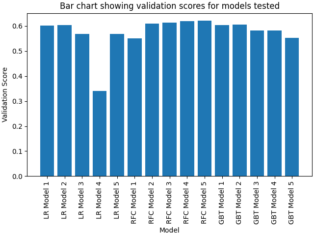

```python
models = ['LR', 'RFC', 'GBT']
xlabels = [f'{models[m]} Model {i}' for m in range(0, 3) for i in range(1, 6)]

fig, ax = plt.subplots(constrained_layout=True)
ax.bar(xlabels, tvModel.validationMetrics)
ax.set_title('Bar chart showing validation scores for models tested')
ax.set_xlabel('Model')
ax.tick_params(axis='x', labelrotation=90)
ax.set_ylabel('Validation Score');
%matplot plt
```

Overall, the models performed similarly, with the exception of logistic regression model 4, which had elasticNetParam set to 1 - effectively setting regularisation to an L1 penalty. It seems that this resulted in important parameters being eliminated.

The best gradient boosted tree classifiers had the shallowest trees. The execution time is unfortunately much longer for gradient boosted trees than the other models tested, so we weren't able to test large numbers of iterations, which may have performed better.

However, given the closeness of the scores above despite quite large differences in parameters, it seems unlikely that a model taking far longer to execute will be justified by the improvement in score.

### Features

We plot the feature importances estimated by the random forest classifier.

```python
feat_importances = pd.Series([tvModel.bestModel.stages[0].featureImportances[i] for i in range(0, 23)],
                             feat_names)
feat_importances = feat_importances.sort_values(ascending=False)
```

[output not shown]

[output not shown]

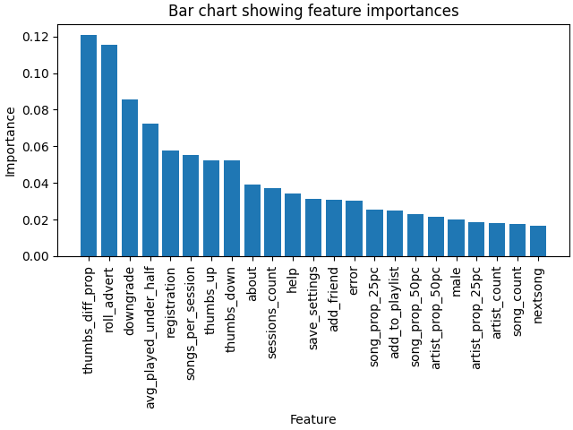

```python
fig, ax = plt.subplots(constrained_layout=True)
ax.bar(feat_importances.index, feat_importances)
ax.set_title('Bar chart showing feature importances')
ax.set_xlabel('Feature')
ax.tick_params(axis='x', labelrotation=90)
ax.set_ylabel('Importance');
%matplot plt
```

With `thumbs_diff_prop` and `avg_played_under_half` both amongst the most important features, it seems that the most influential factor on whether a user will churn is how much they like the music.

The number of adverts played is also influential, and previous visits to the downgrade page indicate churn may be imminent.

Interestingly, features relating to the number of songs played were the least influential factors.

## Conclusion

We set out to predict whether paid users churned (i.e. downgraded or cancelled) from the Sparkify service during a 2 month period, based on their activity throughout the period. Our final model, a random forest classifier, did manage to make correct predictions for the majority of users, but leaves room for improvement, with an F-score of 0.600 to 3 d.p.

It turned out that users' enjoyment of the music was an influential factor in whether or not they churned, as inferred from the proportion of thumbs ups to thumbs downs and the proportion of songs which were skipped.

The number of ads that were played was also influential, and users that had already visited the downgrade page in the past were more likely to go back and complete the action.

Overall usage in terms of number of songs played was not particularly influential.

### Potential improvements

Some potential features were left out of the model, because the overall number of features, and the execution time, would have exploded quite dramatically. These features included location, browsing agent, and artist preferences. These could be explored in greater depth, perhaps distilled with a cluster analysis for example.

In the real world however, even a more successful version of this model may not be particularly useful, because by definition it isn't really predictive for the future - it's trained to classify users that haven't yet churned as secure. In reality, all future churns must come from this group. It may even be the case that many of those users incorrectly predicted to churn did indeed churn in the following weeks.

A more useful model might train on data over a longer time period, for example two years, and predict for each week which users will churn in the near future, based on both overall usage patterns, and the change in those patterns over time.

```python
finish = datetime.datetime.now()
print(finish.strftime("%H:%M:%S"))
```

```
16:39:43
```

```python
print((finish-start))
```

[output not shown]

```
0:25:56.231983
```

[output not shown]